# Parallaxenkorrektur

Um Satelliten- und Radardaten in Übereinstimmung zu bringen ist eine Korrektur der Parallaxe, die durch den Satellitenblickwinkel hervorgerufen wird, nötig. Ein Ansatz ist, sich die NWCSAF-Wolkenhöhe zu nehmen und alle Wolkenpixel zu korrigeren. Eine pixelweise Parallaxenkorrektur hat allerdings folgende Probleme:

- Verzerrung der Wolken,
- Informationslücken (Löcher),
- Überlagerung von Pixeln.

Eine Möglichkeit, diese Probleme zu umgehen, kann sein pro Wolkenobjekt nur eine Höhe anzunehmen und dann die ganze Wolke zu verschieben. Dafür kommen mehrere mögliche Wolkenhöhen in betracht:

1. eine mittlere Wolkenhöhe,
2. eine mittlere Wolkenhöhe ohne Cirruswolken,
3. die maximale Wolkenhöhe,
4. eine Standardhöhe.

Diese objektbasierte Herangehensweise hat allerdings das Problem, dass wir die Objekte irgendwie definieren müssen, z.B. durch Segmentierung mit einem Schwellwert.

```python
import numpy as np
import xarray as xr

import datetime as dt

import load_satellite_data as lsd
import MSGtools as mst

import fixed_colourbar as fc
import nwcsaf_ct_cmap
ct_cmap, ct_norm, ct_label = nwcsaf_ct_cmap.nwcsaf_ct_cmap()

from plotting_tools.colormaps import enhanced_colormap
emap = enhanced_colormap(vmin=210,vmax=300)

import matplotlib.pyplot as plt
%matplotlib inline

import scipy.ndimage as ndi

from analysis_tools import segmentation as sgm
```

## 1. Beispielszene

Dann laden wir uns doch mal eine Beispielszene.

```python
t = dt.datetime(2013,6,18,12,0)
```

```python
sat_data = lsd.load_satellite_data_multichannel(t,['IR_108','HRV'])
```

```
Region suggests use of hdf file
```

```python
cth = mst.get_nwcsaf_prod("CTTH_HEIGHT",t,calibrate=True)
```

```python
ct = mst.get_nwcsaf_prod("CT",t,calibrate=True)
cma = mst.get_nwcsaf_prod("CMa",t,calibrate=True)
```

```python
slon,slat = mst.get_msg_lon_lat('eu')
```

Dann sehen wir uns das Beispiel doch mal an.

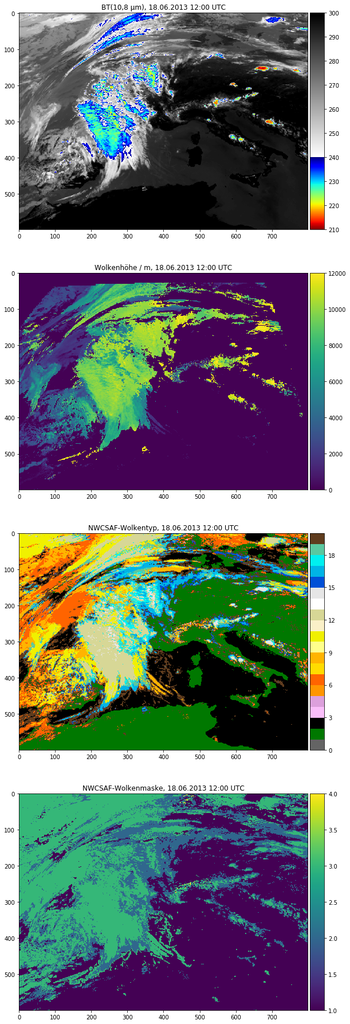

```python
fig,ax = plt.subplots(4,1,figsize=(12,32))
ir_plot = ax[0].imshow(sat_data['IR_108'],vmin=210,vmax=300,cmap=emap)
ax[0].set_title(u"BT(10,8 µm), {}".format(t.strftime("%d.%m.%Y %H:%M UTC")))
fc.colourbar(ir_plot)

cth_plot = ax[1].imshow(cth,vmin=0,vmax=12000)
ax[1].set_title(u"Wolkenhöhe / m, {}".format(t.strftime("%d.%m.%Y %H:%M UTC")))
fc.colourbar(cth_plot)

ct_plot = ax[2].imshow(ct,cmap=ct_cmap,norm=ct_norm)
ct_cbar = fc.colourbar(ct_plot)
ax[2].set_title("NWCSAF-Wolkentyp, {}".format(t.strftime("%d.%m.%Y %H:%M UTC")))

cma_plot = ax[3].imshow(cma)
cma_cbar = fc.colourbar(cma_plot)
ax[3].set_title("NWCSAF-Wolkenmaske, {}".format(t.strftime("%d.%m.%Y %H:%M UTC")))
```

## 1. Objektbasierte Parallaxenkorrektur

Für eine objektbasierte Parallaxenkorrektur benötigen wir Objekte. Dafür müssen wir die Szene segmentieren, um Objekte zu erhalten.

```python
seg_mask = np.ma.masked_less(ct,3)
seg_mask_no_cirrus= np.ma.masked_greater(seg_mask,14)
```

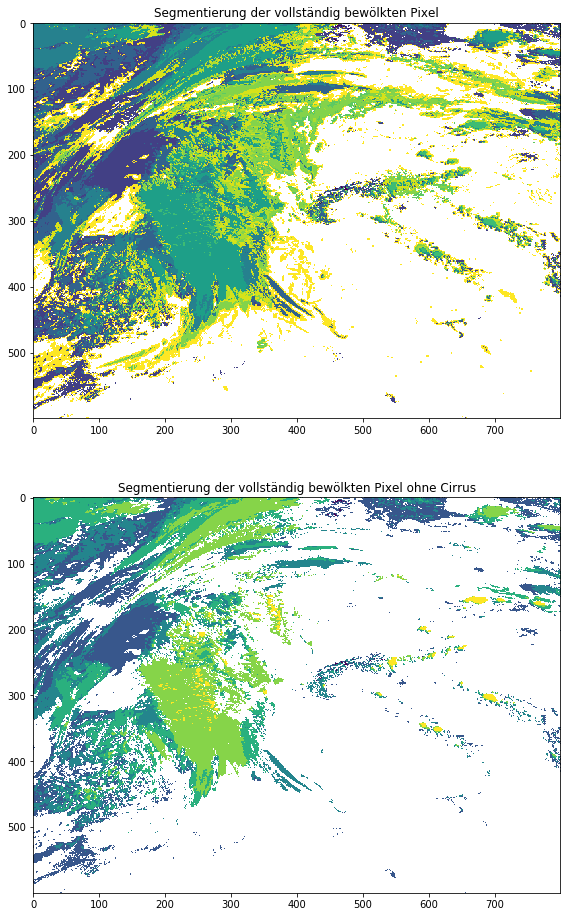

```python
fig,ax = plt.subplots(2,1,figsize=(12,16))
ax[0].imshow(seg_mask)
ax[0].set_title("Segmentierung der vollständig bewölkten Pixel")
ax[1].imshow(seg_mask_no_cirrus)
ax[1].set_title("Segmentierung der vollständig bewölkten Pixel ohne Cirrus")
```

Die Segmentierung ergibt relativ viele zusammenhängende Objekte, vielleicht hilft eine Watershedtransformation, um sie zu trennen.

```python
mask_segmented = sgm.clustering(ct,2,cluster_method='watershed_merge',min_size=1)
```

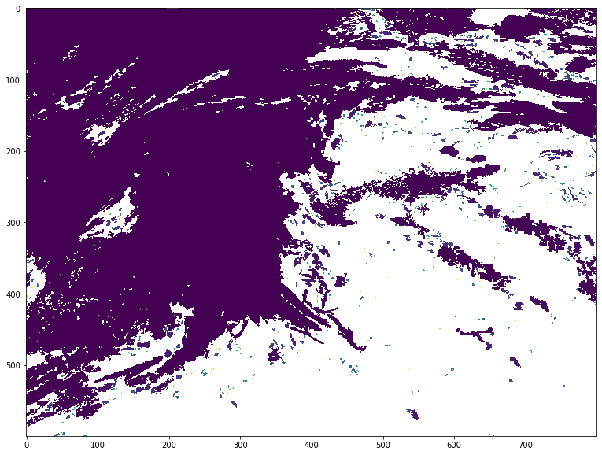

```python
fig,ax = plt.subplots(1,1,figsize=(16,10))
ax.imshow(np.ma.masked_less(mask_segmented,1))
```

## Mittlere Wolkenhöhe pro Wolkenobjekt

Mit dem segmentierten Feld, können wir nun die Wolkenhöhen für jedes Objekt bestimmen.

```python
mean_cloud_height = np.zeros_like(mask_segmented)
```

```python
for oid in np.unique(mask_segmented)[1:]:
    obj_idx = np.where(mask_segmented==oid)

    cloud_heights = cth[obj_idx]

    mean_cloud_height[obj_idx] = np.mean(cloud_heights)
```

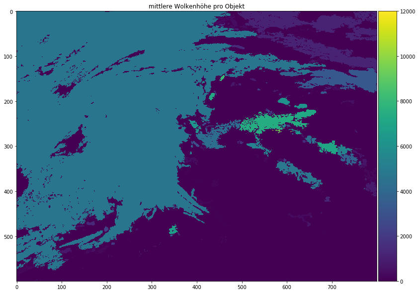

```python
fig,ax = plt.subplots(1,1,figsize=(16,10))
ch_plot = ax.imshow(mean_cloud_height,vmin=0,vmax=12000)
fc.colourbar(ch_plot)
ax.set_title("mittlere Wolkenhöhe pro Objekt")
```

## Mittlere Wolkenhöhe ohne Cirrus

Überlagernde Cirruswolken können eine zu hohe Wolkenhöhe ergeben und eine zu starke Verschiebung bewirken. Deshalb ist es wahrscheinlich gut nur die Wolkenhöhe von nicht semitransparenten Wolken zu benutzen.

```python
mean_cloud_height_no_cirrus = np.zeros_like(mask_segmented)
```

```python
ch_mask = np.ma.masked_where(seg_mask_no_cirrus==True,cth)
```

```python
for oid in np.unique(mask_segmented)[1:]:
    obj_idx = np.where(mask_segmented==oid)

    cloud_heights = ch_mask[obj_idx]

    cloud_heights = cloud_heights[cloud_heights.mask==False]

    if np.all(cloud_heights.mask==True):
        mean_cloud_height_no_cirrus[obj_idx] = np.mean(cth[obj_idx])
    else:
        mean_cloud_height_no_cirrus[obj_idx] = np.mean(cloud_heights)
```

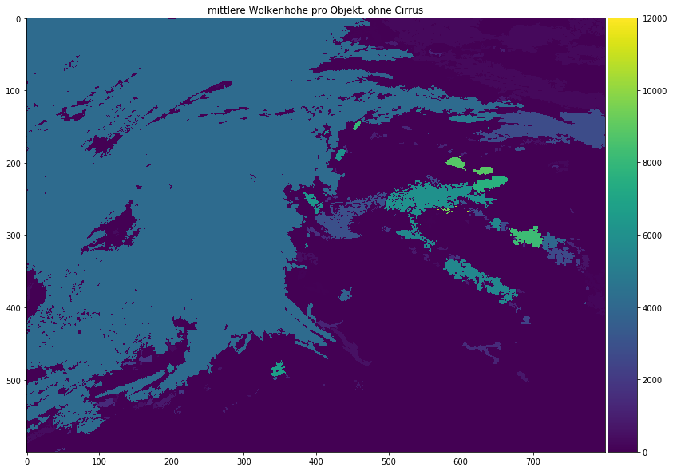

```python
fig,ax = plt.subplots(1,1,figsize=(16,10))
ch_plot = ax.imshow(mean_cloud_height_no_cirrus,vmin=0,vmax=12000)
fc.colourbar(ch_plot)
ax.set_title("mittlere Wolkenhöhe pro Objekt, ohne Cirrus")
```

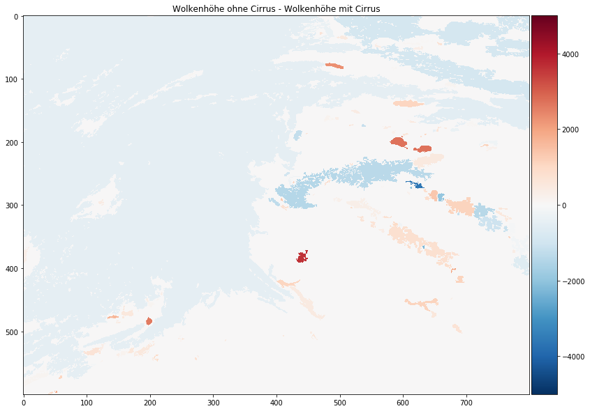

```python
fig,ax = plt.subplots(1,1,figsize=(16,10))
diff_plot = ax.imshow(mean_cloud_height_no_cirrus - mean_cloud_height,vmin=-5000, vmax=5000, cmap='RdBu_r')
fc.colourbar(diff_plot)
ax.set_title("Wolkenhöhe ohne Cirrus - Wolkenhöhe mit Cirrus")
```

## Maximale Wolkenhöhe ohne Cirrus

Jetzt nochmal das gleiche, nur, dass wir die maximale Wolkenhöhe statt dem Mittelwert nehmen.

```python
max_cloud_height_no_cirrus = np.zeros_like(mask_segmented)
```

```python
ch_mask = np.ma.masked_where(seg_mask_no_cirrus==True,cth)
```

```python
for oid in np.unique(mask_segmented)[1:]:
    obj_idx = np.where(mask_segmented==oid)

    cloud_heights = ch_mask[obj_idx]

    cloud_heights = cloud_heights[cloud_heights.mask==False]

    if np.all(cloud_heights.mask==True):
        max_cloud_height_no_cirrus[obj_idx] = np.max(cth[obj_idx])
    else:
        max_cloud_height_no_cirrus[obj_idx] = np.max(cloud_heights)
```

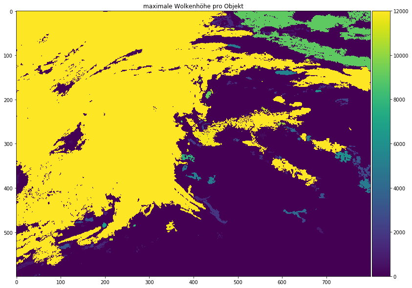

```python
fig,ax = plt.subplots(1,1,figsize=(16,10))
ch_plot = ax.imshow(max_cloud_height_no_cirrus,vmin=0,vmax=12000)
fc.colourbar(ch_plot)
ax.set_title("maximale Wolkenhöhe pro Objekt")
```

Da wird ein Großteil der Wolken sehr hoch. Aber vielleicht bringt das eine gute Übereinstimmung mit den Radarzellen.

## Parallaxenkorrektur

Als nächstes führen wir mit den verschiedenen Objektwolkenhöhen Parallaxenkorrekturen durch und sehen uns an, wo die beste Übereinstimmung mit den Radarsignalen herrscht.

```python
import analysis_tools.parallax
import io_tools.radolan
from analysis_tools import grid_and_interpolation as gi
import skimage.transform
import geooperations as go
```

```python
corr_mean_cirrus = go.parallax_correct_msg(sat_data['IR_108'],slon,slat,mean_cloud_height,'std','eu','rss',1)
corr_mean_no_cirrus = go.parallax_correct_msg(sat_data['IR_108'],slon,slat,mean_cloud_height_no_cirrus,'std','eu','rss',1)
corr_max_no_cirrus = go.parallax_correct_msg(sat_data['IR_108'],slon,slat,max_cloud_height_no_cirrus,'std','eu','rss',1)
```

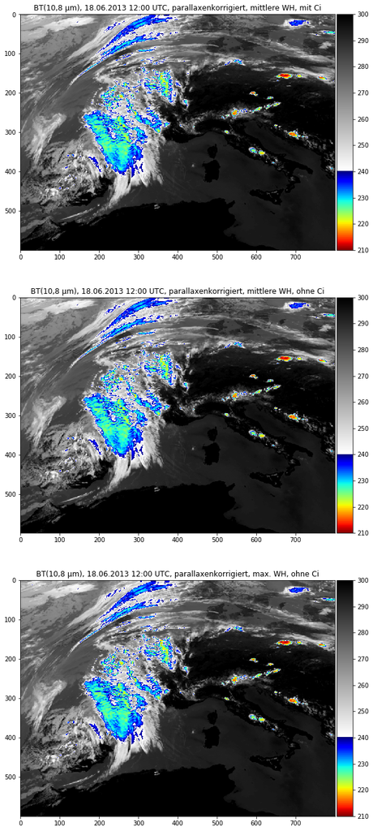

```python
fig,ax = plt.subplots(3,1,figsize=(12,24))
ir_plot = ax[0].imshow(corr_mean_cirrus,vmin=210,vmax=300,cmap=emap)
ax[0].set_title(u"BT(10,8 µm), {}, parallaxenkorrigiert, mittlere WH, mit Ci".format(t.strftime("%d.%m.%Y %H:%M UTC")))
fc.colourbar(ir_plot)

cth_plot = ax[1].imshow(corr_mean_no_cirrus,vmin=210,vmax=300,cmap=emap)
ax[1].set_title(u"BT(10,8 µm), {}, parallaxenkorrigiert, mittlere WH, ohne Ci".format(t.strftime("%d.%m.%Y %H:%M UTC")))
fc.colourbar(cth_plot)

ct_plot = ax[2].imshow(corr_max_no_cirrus,vmin=210,vmax=300,cmap=emap)
ct_cbar = fc.colourbar(ct_plot)
ax[2].set_title(u"BT(10,8 µm), {}, parallaxenkorrigiert, max. WH, ohne Ci".format(t.strftime("%d.%m.%Y %H:%M UTC")))
```

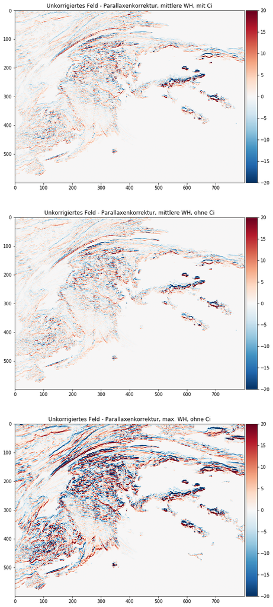

```python
fig,ax = plt.subplots(3,1,figsize=(12,24))
ir_plot = ax[0].imshow(sat_data['IR_108'] - corr_mean_cirrus,vmin=-20,vmax=20,cmap='RdBu_r')
ax[0].set_title(u"Unkorrigiertes Feld - Parallaxenkorrektur, mittlere WH, mit Ci")
fc.colourbar(ir_plot)

cth_plot = ax[1].imshow(sat_data['IR_108'] - corr_mean_no_cirrus,vmin=-20,vmax=20,cmap='RdBu_r')
ax[1].set_title(u"Unkorrigiertes Feld - Parallaxenkorrektur, mittlere WH, ohne Ci")
fc.colourbar(cth_plot)

ct_plot = ax[2].imshow(sat_data['IR_108'] - corr_max_no_cirrus,vmin=-20,vmax=20,cmap='RdBu_r')
ct_cbar = fc.colourbar(ct_plot)
ax[2].set_title(u"Unkorrigiertes Feld - Parallaxenkorrektur, max. WH, ohne Ci")
```

## 2 Pixelbasierte Parallaxenkorrektur

Zum Vergleich führen wir eine pixelweise Parallaxenkorektur mit dem geglätteten Wolkenhöhenfeld durch.

```python
corr_smooth = go.parallax_correct_msg(sat_data['IR_108'],slon,slat,cth,'std','eu','rss',3)
```

```python
from analysis_tools import parallax as px

import l15_msevi.msevi_config as msvc

import sys
sys.path.append("/vols/talos/home/stephan/utils/")
import msg_coord_conv as mcc
```

```python
# do the parallax on coordiantes vector
plon, plat = px.parallax_correction(slon,slat, mean_cloud_height, satlon = 9.5)

# convert the new geodetic coordinates into grid ones
picol,pirow = mcc.ll2cl(plon,plat,'std','rss','oben')
```

```python
region_id = "{}-{}".format('eu','rss')

col_offset = msvc._predefined_regions[region_id][1][0]
row_offset = msvc._predefined_regions[region_id][0][0]

factor = 1.

pirow -= factor * row_offset
picol -= factor * col_offset

# prepare image warping
irow, icol = gi.make_index_set(*slon.shape)

dirow = pirow - irow
dicol = picol - icol

ind =  np.array([irow - dirow, icol - dicol])
```

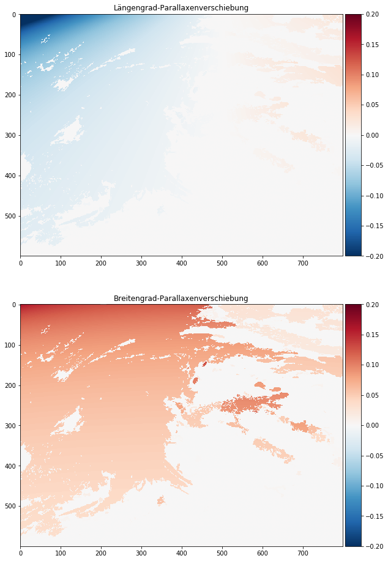

```python
fig,ax = plt.subplots(2,1,figsize=(12,16))
lon_px = ax[0].imshow(slon - plon,vmin=-0.2,vmax=0.2,cmap='RdBu_r')
ax[0].set_title("Längengrad-Parallaxenverschiebung")
fc.colourbar(lon_px)
lat_px = ax[1].imshow(slat - plat,vmin=-0.2,vmax=0.2,cmap='RdBu_r')
ax[1].set_title("Breitengrad-Parallaxenverschiebung")
fc.colourbar(lat_px)
```

## 3 Vergleich für einen Ausschnitt

```python
r = io_tools.radolan.Radolan()
```

```python
r.read_nc(t)
```

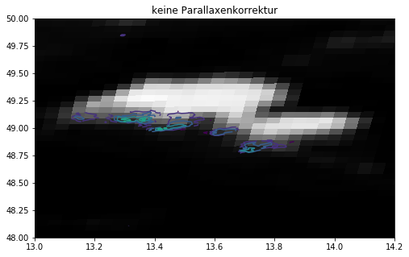

```python
fig,ax = plt.subplots(1,1,figsize=(8,5))
ir_plot = ax.pcolormesh(slon,slat,sat_data['IR_108'],vmin=210,vmax=300,cmap='gray_r')
ax.set_title(u"keine Parallaxenkorrektur")
#fc.colourbar(ir_plot)
r_plot = ax.contour(r.lon,r.lat,np.ma.masked_less(r.data,10))
ax.set_xlim(13,14.2)
ax.set_ylim(48,50)
plt.savefig("/vols/satellite/home/lenk/proj/2019-01_trackingstudie/pics/noparallax.png")
```

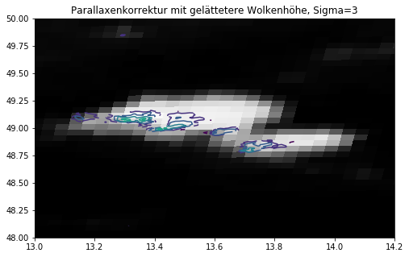

```python
fig,ax = plt.subplots(1,1,figsize=(8,5))
ir_plot = ax.pcolormesh(slon,slat,corr_smooth,vmin=210,vmax=300,cmap='gray_r')
ax.set_title(u"Parallaxenkorrektur mit gelättetere Wolkenhöhe, Sigma=3")
#fc.colourbar(ir_plot)
r_plot = ax.contour(r.lon,r.lat,np.ma.masked_less(r.data,10))
ax.set_xlim(13,14.2)
ax.set_ylim(48,50)
plt.savefig("/vols/satellite/home/lenk/proj/2019-01_trackingstudie/pics/smoothparallax.png")
```

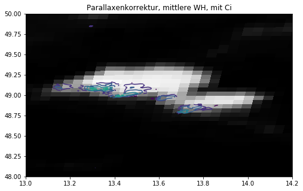

```python
fig,ax = plt.subplots(1,1,figsize=(8,5))
ir_plot = ax.pcolormesh(slon,slat,corr_mean_cirrus,vmin=210,vmax=300,cmap='gray_r')
ax.set_title(u"Parallaxenkorrektur, mittlere WH, mit Ci")
#fc.colourbar(ir_plot)
r_plot = ax.contour(r.lon,r.lat,np.ma.masked_less(r.data,10))
ax.set_xlim(13,14.2)
ax.set_ylim(48,50)
plt.savefig("/vols/satellite/home/lenk/proj/2019-01_trackingstudie/pics/meanparallax.png")
```

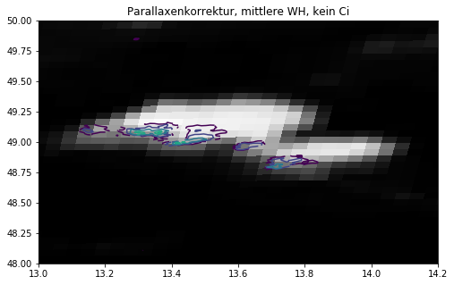

```python
fig,ax = plt.subplots(1,1,figsize=(8,5))
ir_plot = ax.pcolormesh(slon,slat,corr_mean_no_cirrus,vmin=210,vmax=300,cmap='gray_r')
ax.set_title(u"Parallaxenkorrektur, mittlere WH, kein Ci")
#fc.colourbar(ir_plot)
r_plot = ax.contour(r.lon,r.lat,np.ma.masked_less(r.data,10))
ax.set_xlim(13,14.2)
ax.set_ylim(48,50)
plt.savefig("/vols/talos/home/stephan/proj/2019-01_trackingstudie/pics/menanociparallax.png")
```

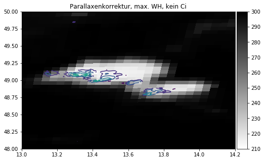

```python
fig,ax = plt.subplots(1,1,figsize=(8,5))
ir_plot = ax.pcolormesh(slon,slat,corr_max_no_cirrus,vmin=210,vmax=300,cmap='gray_r')
ax.set_title(u"Parallaxenkorrektur, max. WH, kein Ci")
fc.colourbar(ir_plot)
r_plot = ax.contour(r.lon,r.lat,np.ma.masked_less(r.data,10))
ax.set_xlim(13,14.2)
ax.set_ylim(48,50)
plt.savefig("/vols/satellite/home/lenk/proj/2019-01_trackingstudie/pics/maxnociparallax.png")
```

Die Korrektur mit der maximalen Wolkenhöhe, hat wahrscheinlich die beste Übereinstimmung zwischen Wolken und Niederschlag. Allerdings treten hier an den südlichen Wolkenrändern Artefakte auf. Ähnlich sieht es auch für die pixelweise Korrektur mit der geglätteten Wolkenhöhe aus. Am zweitbesten ist die Variante mit mittlerer Objektwolkenhöhe und ausmaskierten Cirruswolken.